# Model-Performance-Rpart

Rich McGowan

April 25, 2018

#### The purpose of this analysis is to perform and assess a Recursive Partitioning (rpart) Regression Tree model for predicting Total Course Enrollment.

#### The first step is to initialize the project: After the project has been created in the target directory make sure the ProjectTemplate package is installed and loaded. The COURSE_CAPACITY_DATA.csv and TOTAL_ENRL_ATTEMPTS_BY_COURSE.csv files have been moved into the Data folder of the project template and will be loaded into the environment. This will also load all necessary packages (designated in/by the Config file of the project). For this analysis environment the “rpart”" and “rpart.plot”" packages are required.

#### The COURSE_CAPACITY_DATA.csv file and the TOTAL_ENRL_ATTEMPTS_BY_COURSE file.csv contain approximately 13K rows of course schedule statisics for terms between Fall of 2016 and the Spring of 2018. The data frame is intended to facilitate the prediction of ultimate Enrollment Totals per scheduled course (for all primary/enrollmment scheduled sections).

```r
course_capacity_local <- tbl_df(COURSE.CAPACITY.DATA)
total_enrl_attempts_local <- tbl_df(TOTAL.ENRL.ATTEMPTS.BY.COURSE)
```

#### Combine the appropriate columns in the 2 data frames (i.e. add the TotalAttempts column from total_enrl_attempts_local to course_capacity_local matching on CourseID and Term)

```r
combined_data_local <- merge(course_capacity_local, total_enrl_attempts_local, by= c('CourseID','Term'))
```

#### Filter all pre Spring 2018 rows from the combined_data_local dataframe to isolate a (Fall 2016 - Fall 2017 only) training dataset. Filter all Spring 2018 rows from the combined_data_local dataframe to isolate a (Spring 2018 only) dataset.

```r
training_data_local <- combined_data_local %>% filter(Term < 2182)
test_data_local <- combined_data_local %>% filter(Term >= 2182)
```

#### Exclude columns of the training_data_local and test_data_local datasets to minimized them so they only include variables of interest to the model.

```r
training_data_minimized <- training_data_local %>% select(EnrlTotal, TotalSections, TotalCapacity,TotalAttempts)
test_data_minimized <- test_data_local %>% select(EnrlTotal, TotalSections, TotalCapacity,TotalAttempts)
```

#### Create a Recursive Partition Regression Tree Model to explain the relationship between Response Variable (EnrlTotal-from the training_data_local dataset) and several explanatory variables from the traning_data_local dataset.

```r
fit_rpart <- rpart(EnrlTotal ~ ., data = training_data_minimized, method = "anova")
fit_rpart
```

```
## n= 9453
##
## node), split, n, deviance, yval
##       * denotes terminal node
##
##  1) root 9453 66366160.0  48.47615
##    2) TotalCapacity< 160.5 8670 10965150.0  31.27578
##      4) TotalCapacity< 61.5 6808  1448060.0  18.67318
##        8) TotalCapacity< 30.5 4445   291067.7  11.39663 *
##        9) TotalCapacity>=30.5 2363   478915.1  32.36098 *
##      5) TotalCapacity>=61.5 1862  4482322.0  77.35446
##       10) TotalAttempts< 222.5 840   619057.7  49.93690 *
##       11) TotalAttempts>=222.5 1022  2712821.0  99.88943 *
##    3) TotalCapacity>=160.5 783 24433780.0 238.93230
##      6) TotalAttempts< 841.5 418  3824364.0 137.50720
##       12) TotalAttempts< 214.5 166   713188.3  52.58434 *
##       13) TotalAttempts>=214.5 252  1125388.0 193.44840 *
##      7) TotalAttempts>=841.5 365 11385050.0 355.08490
##       14) TotalCapacity< 433 257  1816274.0 261.68090 *
##       15) TotalCapacity>=433 108  1991151.0 577.35190
##         30) TotalCapacity< 655 64   349862.5 492.26560 *
##         31) TotalCapacity>=655 44   504002.4 701.11360 *
```

#### Plot the resulting tree using the rpart.plot function to display a more succint plot of the tree

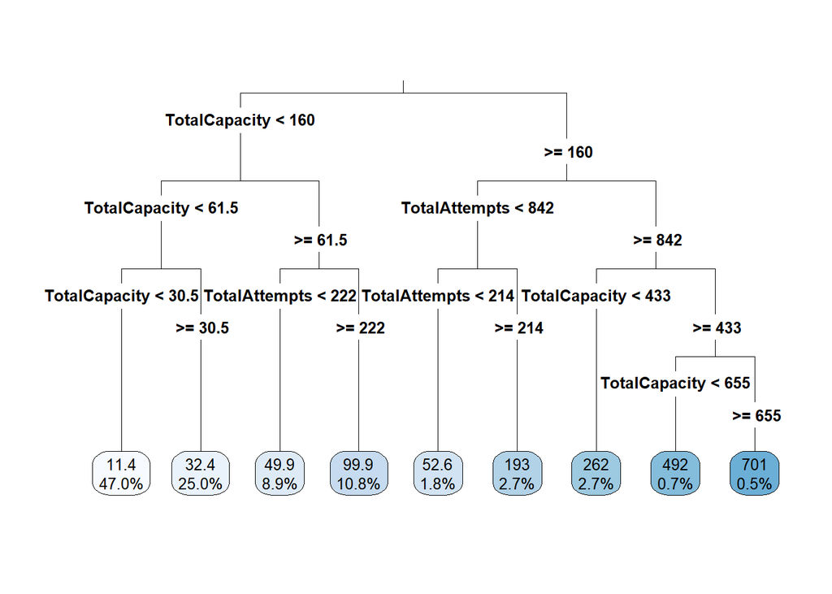

```r
rpart.plot(fit_rpart, type = 3, digits = 3, fallen.leaves = TRUE)
```

#### Run the predict function on the test dataset and analyze the results by calculating the Mean Absolute Error of the prediction

```r
predict_rpart <- predict(fit_rpart, test_data_minimized)
MeanAbsoluteError <- MAE(test_data_minimized$EnrlTotal,predict_rpart)
print(paste("The Mean Absolute Error of the Prediction is", round(MeanAbsoluteError, digits = 2)))
```

```
## [1] "The Mean Absolute Error of the Prediction is 15.85"
```

## CONCLUSION-The Recursive Partition Regression Tree Model resulted in a Mean Absolute Error of the predicted Total Enrollment by Course is well witin the acceptable range since there are courses and class sections that have very large enrollment capacities.

# Model-Performance-Rpart

Rich McGowan

April 25, 2018

#### The purpose of this analysis is to perform and assess a Recursive Partitioning (rpart) Regression Tree model for predicting Total Course Enrollment.

#### The first step is to initialize the project: After the project has been created in the target directory make sure the ProjectTemplate package is installed and loaded. The COURSE_CAPACITY_DATA.csv and TOTAL_ENRL_ATTEMPTS_BY_COURSE.csv files have been moved into the Data folder of the project template and will be loaded into the environment. This will also load all necessary packages (designated in/by the Config file of the project). For this analysis environment the “rpart”" and “rpart.plot”" packages are required.

#### The COURSE_CAPACITY_DATA.csv file and the TOTAL_ENRL_ATTEMPTS_BY_COURSE file.csv contain approximately 13K rows of course schedule statisics for terms between Fall of 2016 and the Spring of 2018. The data frame is intended to facilitate the prediction of ultimate Enrollment Totals per scheduled course (for all primary/enrollmment scheduled sections).

```r
course_capacity_local <- tbl_df(COURSE.CAPACITY.DATA)
total_enrl_attempts_local <- tbl_df(TOTAL.ENRL.ATTEMPTS.BY.COURSE)
```

#### Combine the appropriate columns in the 2 data frames (i.e. add the TotalAttempts column from total_enrl_attempts_local to course_capacity_local matching on CourseID and Term)

```r
combined_data_local <- merge(course_capacity_local, total_enrl_attempts_local, by= c('CourseID','Term'))
```

#### Filter all pre Spring 2018 rows from the combined_data_local dataframe to isolate a (Fall 2016 - Fall 2017 only) training dataset. Filter all Spring 2018 rows from the combined_data_local dataframe to isolate a (Spring 2018 only) dataset.

```r
training_data_local <- combined_data_local %>% filter(Term < 2182)
test_data_local <- combined_data_local %>% filter(Term >= 2182)
```

#### Exclude columns of the training_data_local and test_data_local datasets to minimized them so they only include variables of interest to the model.

```r
training_data_minimized <- training_data_local %>% select(EnrlTotal, TotalSections, TotalCapacity,TotalAttempts)
test_data_minimized <- test_data_local %>% select(EnrlTotal, TotalSections, TotalCapacity,TotalAttempts)
```

#### Create a Recursive Partition Regression Tree Model to explain the relationship between Response Variable (EnrlTotal-from the training_data_local dataset) and several explanatory variables from the traning_data_local dataset.

```r
fit_rpart <- rpart(EnrlTotal ~ ., data = training_data_minimized, method = "anova")
fit_rpart
```

```
## n= 9453
##
## node), split, n, deviance, yval
##       * denotes terminal node
##
##  1) root 9453 66366160.0  48.47615
##    2) TotalCapacity< 160.5 8670 10965150.0  31.27578
##      4) TotalCapacity< 61.5 6808  1448060.0  18.67318
##        8) TotalCapacity< 30.5 4445   291067.7  11.39663 *
##        9) TotalCapacity>=30.5 2363   478915.1  32.36098 *
##      5) TotalCapacity>=61.5 1862  4482322.0  77.35446
##       10) TotalAttempts< 222.5 840   619057.7  49.93690 *
##       11) TotalAttempts>=222.5 1022  2712821.0  99.88943 *
##    3) TotalCapacity>=160.5 783 24433780.0 238.93230
##      6) TotalAttempts< 841.5 418  3824364.0 137.50720
##       12) TotalAttempts< 214.5 166   713188.3  52.58434 *
##       13) TotalAttempts>=214.5 252  1125388.0 193.44840 *
##      7) TotalAttempts>=841.5 365 11385050.0 355.08490
##       14) TotalCapacity< 433 257  1816274.0 261.68090 *
##       15) TotalCapacity>=433 108  1991151.0 577.35190
##         30) TotalCapacity< 655 64   349862.5 492.26560 *
##         31) TotalCapacity>=655 44   504002.4 701.11360 *
```

#### Plot the resulting tree using the rpart.plot function to display a more succint plot of the tree

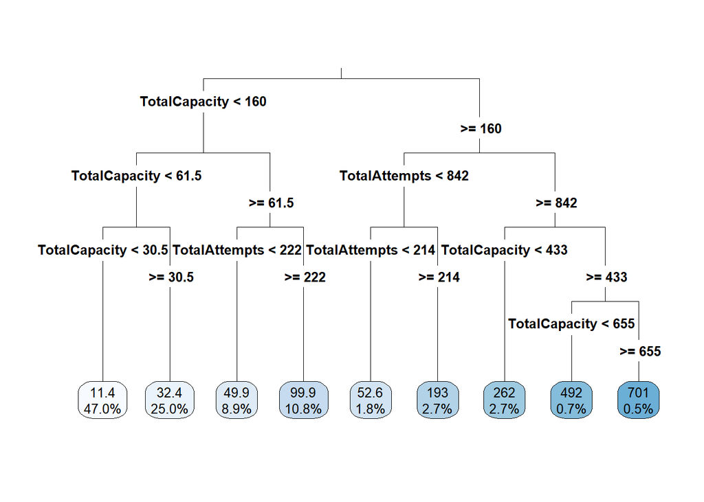

```r
rpart.plot(fit_rpart, type = 3, digits = 3, fallen.leaves = TRUE)
```

#### Run the predict function on the test dataset and analyze the results by calculating the Mean Absolute Error of the prediction

```r
predict_rpart <- predict(fit_rpart, test_data_minimized)
MeanAbsoluteError <- MAE(test_data_minimized$EnrlTotal,predict_rpart)
print(paste("The Mean Absolute Error of the Prediction is", round(MeanAbsoluteError, digits = 2)))
```

```
## [1] "The Mean Absolute Error of the Prediction is 15.85"
```